# Functional Form & Scaling

Natasha Kang

Xiamen University, Chow Institute

April, 2026

## Roadmap

1. **Functional forms**: logarithms, quadratics, interactions
2. Scaling and beta coefficients

## Linear in Parameters, Not in Variables

- The linear regression model is **linear in the parameters**, not necessarily in the variables.
- Valid linear regression: $\;y = \beta_0 + \beta_1 \sqrt{x} + u$
- **Not** a linear regression: $\;y = \frac{1}{\beta_0 + \beta_1 x} + u$
- This means we can transform the variables — logarithms, polynomials, interactions — and still estimate with OLS.

## Why Logarithms?

**Example**: the Cobb-Douglas production function with a multiplicative shock

$$Y_i = A K_i^{\alpha} L_i^{\gamma} e^{u_i}$$

is nonlinear in the parameters. But taking logs:

$$\log(Y_i) = \log(A) + \alpha \log(K_i) + \gamma \log(L_i) + u_i$$

This is now linear and can be estimated by OLS.

## Why Logarithms? (cont.)

Beyond linearizing multiplicative models:

- Many economic variables (income, prices, firm size) are **right-skewed**. Extreme values can have high leverage in OLS. Taking logs compresses the scale and reduces the influence of outliers.
- If $\log(Y) \mid X$ is approximately normal, the log-linear model is correctly specified and the normality assumption on errors holds.

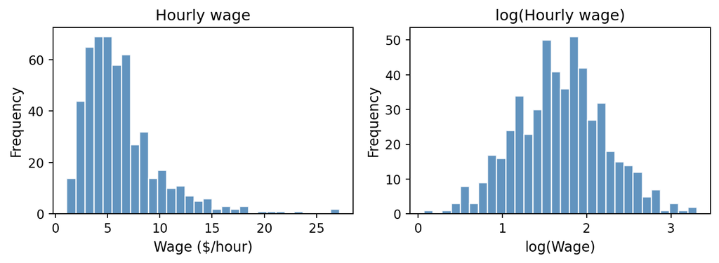

## Four Log-Linear Models

We can apply the log transformation to $y$, to $x$, to both, or to neither. Each choice changes how $\beta_1$ is interpreted:

| Model | Specification | Interpretation of $\beta_1$ |
| --- | --- | --- |
| Level-level | $y = \beta_0 + \beta_1 x + u$ | $\Delta y = \beta_1 \Delta x$ |
| Level-log | $y = \beta_0 + \beta_1 \log(x) + u$ | $\Delta y \approx (\beta_1/100)\, \%\Delta x$ |
| Log-level | $\log(y) = \beta_0 + \beta_1 x + u$ | $\%\Delta y \approx (100\beta_1)\, \Delta x$ |
| Log-log | $\log(y) = \beta_0 + \beta_1 \log(x) + u$ | $\%\Delta y \approx \beta_1\, \%\Delta x$ |

## Deriving the Log-Level Interpretation

In the model $\log(y) = \beta_0 + \beta_1 x + u$, consider a change $\Delta x$:

$$\log(y + \Delta y) - \log(y) = \beta_1 \Delta x$$

The left side is $\log(1 + \Delta y / y) \approx \Delta y / y$ for small $\Delta y / y$.

So:

$$\frac{\Delta y}{y} \approx \beta_1 \Delta x \quad\Longrightarrow\quad \%\Delta y \approx (100\beta_1)\, \Delta x$$

This approximation relies on $\log(1+r) \approx r$ for small $r$.

## Deriving the Level-Log Interpretation

In the model $y = \beta_0 + \beta_1 \log(x) + u$, consider a change $\Delta x$:

$$\Delta y = \beta_1 [\log(x + \Delta x) - \log(x)] = \beta_1 \log\!\left(1 + \frac{\Delta x}{x}\right)$$

For small $\Delta x / x$, using $\log(1+r) \approx r$:

$$\Delta y \approx \beta_1 \cdot \frac{\Delta x}{x} = \frac{\beta_1}{100} \cdot \%\Delta x$$

## Deriving the Log-Log Interpretation

In the model $\log(y) = \beta_0 + \beta_1 \log(x) + u$, consider a change $\Delta x$:

$$\log(y + \Delta y) - \log(y) = \beta_1 [\log(x + \Delta x) - \log(x)]$$

Applying $\log(1+r) \approx r$ to both sides:

$$\frac{\Delta y}{y} \approx \beta_1 \cdot \frac{\Delta x}{x} \quad\Longrightarrow\quad \%\Delta y \approx \beta_1\, \%\Delta x$$

$\beta_1$ is the **elasticity** of $y$ with respect to $x$: the percent change in $y$ for a one percent change in $x$.

## When the Approximation Breaks Down

- All three derivations used $\log(1+r) \approx r$, which is accurate only for small $r$. What if the change is large?
- For large changes, use the **exact** formula. From the log-level model:

$$\log(y + \Delta y) - \log(y) = \beta_1 \Delta x \quad\Longrightarrow\quad \frac{y + \Delta y}{y} = e^{\beta_1 \Delta x}$$

- Therefore:

$$\frac{\Delta y}{y} = e^{\beta_1 \Delta x} - 1 \quad\Longrightarrow\quad \%\Delta y = 100 \cdot \big[\exp(\beta_1 \Delta x) - 1\big]$$

- **Example**: If $\hat\beta_1 = 0.30$ for $\Delta x = 1$:
  - Approximate: $30\%$ increase
  - Exact: $100 \cdot (e^{0.30} - 1) = 34.99\%$ increase

## Example: Education and Wages

$$\widehat{\log(\text{wage})} = 0.584 + 0.083\; \text{educ}$$

- **Approximate**: each additional year of education is associated with an $8.3\%$ increase in hourly wage.
- **Exact**: $100 \cdot (e^{0.083} - 1) = 8.65\%$.
- The approximation is good here because $0.083$ is small.

## Example: CEO Salary and Firm Sales

$$\widehat{\log(\text{salary})} = 4.82 + 0.257\; \log(\text{sales})$$

- This is a **log-log** model: $\hat\beta_1 = 0.257$ is the estimated elasticity.
- A $1\%$ increase in firm sales is associated with a $0.257\%$ increase in CEO salary.

## Units of Measurement and Logs

If we change the units of sales, does the estimated elasticity change?

In the CEO salary regression, sales are measured in millions of dollars:

$$\widehat{\log(\text{salary})} = 4.82 + 0.257\; \log(\text{sales})$$

Suppose we re-measure sales in **thousands** of dollars. Then $\text{sales}_{\text{new}} = 1000 \cdot \text{sales}$, and:

$$\log(\text{sales}_{\text{new}}) = \log(1000) + \log(\text{sales})$$

The slope $\hat\beta_1 = 0.257$ is **unchanged** — only the intercept shifts.

In log-log models, the elasticity is invariant to units of measurement.

## Roadmap

1. **Functional forms**: logarithms, **quadratics**, interactions
2. Scaling and beta coefficients

## Quadratic Models

Consider the specification:

$$y = \beta_0 + \beta_1 x + \beta_2 x^2 + u$$

The **marginal effect** of $x$ on $y$:

$$\frac{\partial E[y \mid x]}{\partial x} = \beta_1 + 2\beta_2 x$$

- The marginal effect is **not constant** — it depends on $x$.
- The sign of $\beta_2$ determines whether the effect is increasing ($\beta_2 > 0$) or decreasing ($\beta_2 < 0$) in $x$.

## Example: Experience and Wages

Data: *wage1*

$$\widehat{\text{wage}} = \underset{(0.35)}{3.73} + \underset{(0.04)}{0.298}\; \text{exper} \underset{(0.0009)}{- 0.0061}\; \text{exper}^2$$

Marginal effect:

$$\frac{\partial \widehat{\text{wage}}}{\partial \text{exper}} = 0.298 - 2(0.0061) \cdot \text{exper} = 0.298 - 0.0122 \cdot \text{exper}$$

- At $\text{exper} = 0$: marginal effect $= \$0.30$/hour per year.
- At $\text{exper} = 10$: marginal effect $= \$0.18$/hour per year.
- **Turning point**: $\text{exper}^* = 0.298 / 0.0122 \approx 24.4$.

## Interpreting the Turning Point

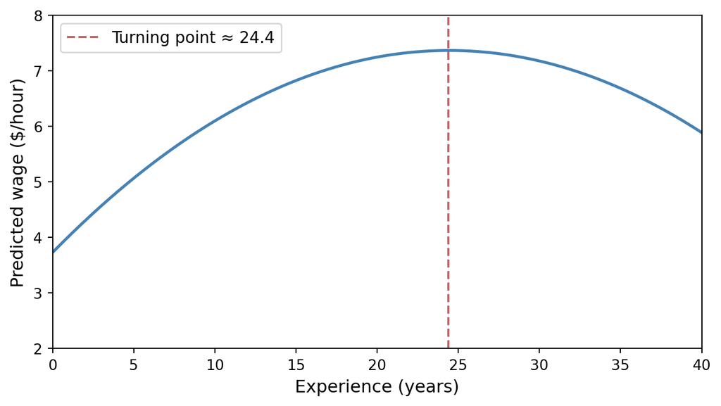

Does this mean returns to experience become **negative** after 24 years? Not necessarily — could be OVB (e.g., omitting education) or misspecification (e.g., $\log(\text{wage})$ may be more appropriate).

## Quadratics: Housing Prices

A quadratic is a local approximation — should we take it literally everywhere?

$$\begin{aligned}
\widehat{\log(\text{price})} = \underset{(0.57)}{13.39} &\underset{(0.11)}{- 0.902}\; \log(\text{nox}) \underset{(0.04)}{- 0.087}\; \log(\text{dist}) \\
&\underset{(0.17)}{- 0.545}\; \text{rooms} + \underset{(0.01)}{0.062}\; \text{rooms}^2 \underset{(0.006)}{- 0.048}\; \text{stratio}
\end{aligned}$$

Marginal effect of rooms:

$$\frac{\partial \widehat{\log(\text{price})}}{\partial \text{rooms}} = -0.545 + 0.124 \cdot \text{rooms}$$

## Quadratics: Housing Prices (cont.)

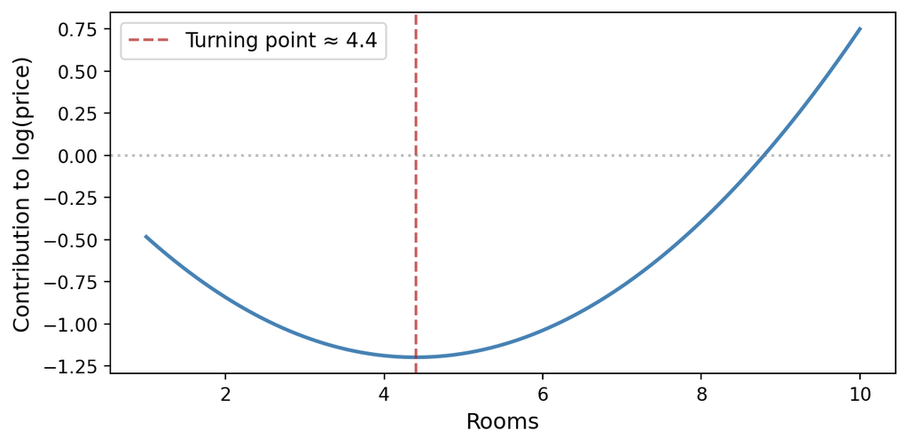

- The model predicts that a house with 2 rooms is worth *more* than one with 4 rooms — nonsensical.
- The quadratic is a local approximation; it should not be trusted at extreme values.
- In practice, ~95% of houses in the sample have 5–8 rooms — few observations inform the extremes.

## Roadmap

1. **Functional forms**: logarithms, quadratics, **interactions**
2. Scaling and beta coefficients

## Interaction Terms

Quadratic terms capture curvature in a single variable. But the second-order Taylor expansion of $f(x_1, x_2)$ also introduces **cross-terms**:

$$\begin{aligned}
y &= f(x_1, x_2) \\
&\approx \beta_0 + \beta_1 x_1 + \beta_2 x_2 + \beta_3 x_1 x_2 + \beta_4 x_1^2 + \beta_5 x_2^2 + \cdots
\end{aligned}$$

The interaction term $x_1 x_2$ allows the effect of $x_1$ to depend on $x_2$:

$$\frac{\partial E[y \mid x_1, x_2]}{\partial x_1} = \beta_1 + \beta_3 x_2$$

## Example: Attendance and Exam Performance

Data: *attend*

$$\begin{aligned}
\widehat{\text{stndfnl}} = \underset{(1.36)}{2.05} &\underset{(0.01)}{- 0.0067}\; \text{atndrte} \underset{(0.48)}{- 1.63}\; \text{priGPA} \\
&\underset{(0.10)}{- 0.128}\; \text{ACT} + \underset{(0.10)}{0.296}\; \text{priGPA}^2 \\
&+ \underset{(0.002)}{0.0045}\; \text{ACT}^2 + \underset{(0.004)}{0.0056}\; \text{priGPA} \cdot \text{atndrte}
\end{aligned}$$

Partial effect of attendance (only $\text{atndrte}$ and its interaction appear):

$$\frac{\partial \widehat{\text{stndfnl}}}{\partial \text{atndrte}} = -0.0067 + 0.0056 \cdot \text{priGPA}$$

## Average Partial Effect

Evaluating at $\overline{\text{priGPA}} = 2.59$:

$$\widehat{APE}_{\text{atndrte}} = -0.0067 + 0.0056 \times 2.59 = 0.0078$$

- At the average prior GPA, a one-percentage-point increase in attendance is associated with a $0.0078$ standard deviation increase in final exam score.
- For a student with $\text{priGPA} = 2.0$: effect $= -0.0067 + 0.0056(2.0) = 0.0045$.
- For a student with $\text{priGPA} = 3.5$: effect $= -0.0067 + 0.0056(3.5) = 0.013$.

Attendance matters more for students with higher prior GPA.

## Interpreting the Main Effect

In the model $y = \beta_0 + \beta_1 x_1 + \beta_2 x_2 + \beta_3 x_1 x_2 + u$:

$\beta_1$ gives the effect of $x_1$ when $x_2 = 0$.

In the attendance example, $\beta_1 = -0.0067$ is the effect of attendance for a student with $\text{priGPA} = 0$ — not meaningful.

We want the effect at a meaningful value of $x_2$, such as its sample mean.

## Mean-Centering the Interaction

**Solution**: replace $x_1 x_2$ with $(x_1 - \bar{x}_1)(x_2 - \bar{x}_2)$ in the interaction term only:

$$y = \alpha_0 + \alpha_1 x_1 + \alpha_2 x_2 + \beta_3 (x_1 - \bar{x}_1)(x_2 - \bar{x}_2) + u$$

- The interaction coefficient $\beta_3$ is unchanged — centering is just a reparameterization.
- But now $\alpha_1$ gives the effect of $x_1$ at $x_2 = \bar{x}_2$: this is the **average partial effect**.

In the attendance example: replace $\text{priGPA} \cdot \text{atndrte}$ with $(\text{priGPA} - \overline{\text{priGPA}}) \cdot \text{atndrte}$. Then $\hat\alpha_1$ directly estimates the APE of attendance — and OLS reports its standard error, so we get inference for free.

## Roadmap

1. Functional forms: logarithms, quadratics, interactions
2. **Scaling and beta coefficients**

## Does Scaling Matter?

We’ve seen how transformations change the model. But even without transforming, the choice of *units* affects the numbers we report.

Consider $y_i = \hat\beta_0 + \hat\beta_1 x_i + \hat{u}_i$.

**Question**: If we change the units of $x$ or $y$ (e.g., dollars $\to$ thousands of dollars), what happens to:

- The OLS estimates $\hat\beta_0$, $\hat\beta_1$?
- The $R^2$?
- The $t$-statistics and $F$-statistics?

## Scaling the Independent Variable

**Adding a constant**: $x_i^* = x_i + c$

$$y_i = \hat\beta_0^* + \hat\beta_1^* x_i^* + \hat{u}_i^* = (\hat\beta_0^* + \hat\beta_1^* c) + \hat\beta_1^* x_i + \hat{u}_i^*$$

Matching coefficients: $\hat\beta_1 = \hat\beta_1^*$ (unchanged), $\hat\beta_0 = \hat\beta_0^* + \hat\beta_1^* c$.

**Multiplying by a constant**: $x_i^* = a\, x_i$

$$\hat\beta_1 = a\, \hat\beta_1^* \quad\Longrightarrow\quad \hat\beta_1^* = \hat\beta_1 / a$$

The slope **rescales inversely** with the unit change.

## Scaling the Dependent Variable

**Adding a constant**: $y_i^* = y_i + c$

$$\hat\beta_0^* = \hat\beta_0 + c, \quad \hat\beta_1^* = \hat\beta_1$$

**Multiplying by a constant**: $y_i^* = a\, y_i$

$$\hat\beta_0^* = a\, \hat\beta_0, \quad \hat\beta_1^* = a\, \hat\beta_1$$

## Summary: Effects of Data Scaling

For the model $y_i = \beta_0 + \beta_1 x_i + u_i$:

| Transformation | Intercept | Slope | $R^2$ |
| --- | --- | --- | --- |
|  | *Independent variable* |  |  |
| $x + c$ | $\beta_0 - c\beta_1$ | $\beta_1$ | unchanged |
| $a \cdot x$ | $\beta_0$ | $\beta_1 / a$ | unchanged |
|  | *Dependent variable* |  |  |
| $y + c$ | $\beta_0 + c$ | $\beta_1$ | unchanged |
| $a \cdot y$ | $a\beta_0$ | $a\beta_1$ | unchanged |

- $R^2$ is **invariant** to linear rescaling. For slope coefficients, $t$-statistics and $F$-statistics are also invariant (the intercept $t$-statistic can change under additive shifts).
- Slope coefficients and their standard errors rescale in lockstep.

## Why This Matters

- Scaling does not change the **substance** of results — only their presentation.
- Choose units that make coefficients **easy to interpret**:
  - Income in thousands (not raw dollars) so coefficients aren’t tiny.
  - Population in millions rather than raw counts.
- **Never compare** coefficient magnitudes across variables with different units. A “larger” coefficient may simply reflect a smaller unit of measurement. So how *do* we compare effects across variables?

## Beta Coefficients

**Problem**: How do we compare the relative importance of regressors measured in different units?

**Solution**: **Standardize** all variables to have mean zero and standard deviation one.

Original model:

$$y_i = \beta_0 + \beta_1 x_{i1} + \beta_2 x_{i2} + \cdots + \beta_k x_{ik} + u_i$$

Standardized model:

$$\frac{y_i - \bar{y}}{\hat\sigma_y} = \beta_1^* \frac{x_{i1} - \bar{x}_1}{\hat\sigma_1} + \beta_2^* \frac{x_{i2} - \bar{x}_2}{\hat\sigma_2} + \cdots + \beta_k^* \frac{x_{ik} - \bar{x}_k}{\hat\sigma_k} + u_i^*$$

## Beta Coefficients (cont.)

The standardized coefficient:

$$\beta_j^* = \frac{\hat\sigma_j}{\hat\sigma_y} \hat\beta_j$$

**Interpretation**: a one standard deviation increase in $x_j$ is associated with a $\beta_j^*$ standard deviation change in $y$, holding all else equal.

- Beta coefficients are **unit-free** — they can be compared across variables.
- No intercept in the standardized regression (all variables are demeaned).

## Example: Pollution and Housing Prices

$$\begin{aligned}
\widehat{\text{price}} = \underset{(5055)}{20{,}871} &\underset{(354)}{- 2{,}706}\; \text{nox} \underset{(33)}{- 154}\; \text{crime} \\
&+ \underset{(394)}{6{,}726}\; \text{rooms} \underset{(188)}{- 1{,}027}\; \text{dist} \underset{(127)}{- 1{,}148}\; \text{stratio}
\end{aligned}$$

Standardized regression:

$$\begin{aligned}
\widehat{z_{\text{price}}} = &\underset{(0.04)}{-0.340}\; z_{\text{nox}} \underset{(0.03)}{- 0.143}\; z_{\text{crime}} \\
&+ \underset{(0.03)}{0.514}\; z_{\text{rooms}} \underset{(0.04)}{- 0.235}\; z_{\text{dist}} \underset{(0.03)}{- 0.270}\; z_{\text{stratio}}
\end{aligned}$$

- **Rooms** has the largest standardized effect ($0.514$), followed by **pollution** ($-0.340$).
- Pollution has a larger effect than crime ($0.340$ vs. $0.143$) — hard to see from unstandardized coefficients alone.

## Summary

- The linear regression model is **linear in the parameters**, not necessarily in the variables. Transformations (logs, polynomials, interactions) expand what OLS can capture.
- **Logarithmic models** give percentage-change interpretations; the log-log coefficient is an elasticity.
- **Quadratic and interaction terms** allow marginal effects to vary with $x$. Always compute the marginal effect — do not interpret individual coefficients in isolation.
- **Scaling** changes the presentation of results, not the substance. Use beta coefficients to compare magnitudes across variables.

## What’s Next

**Lecture 4b — Dummy Variables**:

- Binary regressors: intercept and slope shifts
- Structural breaks and the Chow test
- The linear probability model